# Week 02: Decision Trees

Ziyuan Huang

Last Updated: March 26, 2026

# Introduction

Decision Trees are one of the most intuitive and powerful models in machine learning. They are versatile — capable of performing both classification and regression — and they form the fundamental building blocks for more advanced algorithms like **Random Forests**.

Think of a Decision Tree like a game of “20 Questions.” You start with a question about your data, and the answer leads you to the next question, until you arrive at a final prediction.

> *“Decision Trees are intuitive, and their decisions are easy to interpret. Such models are often called **white box models**. In contrast, Random Forests or neural networks are generally considered **black box models** — they make great predictions, but it is usually hard to explain in simple terms why a particular prediction was made.”* — A. Géron **[1]**

> *“Tree-based models are a class of nonparametric algorithms that work by partitioning the feature space into a number of smaller (non-overlapping) regions with similar response values using a set of splitting rules… decision trees offer many benefits; however, they typically lack in predictive performance compared to more complex algorithms. However, future chapters will discuss powerful ensemble algorithms — like random forests and gradient boosting machines — which are constructed by combining together many decision trees in a clever way.”* — B. C. Boehmke & B. M. Greenwell **[2]**

**Learning Objectives:**

By the end of this tutorial, you will be able to:

1. Understand the core structure of a Decision Tree (nodes, branches, leaves).
2. Explain how the **CART algorithm** chooses splits using **Gini Impurity** and **Entropy**.
3. Build, visualize, and interpret a Decision Tree in R.
4. Estimate **class probabilities** from a tree.
5. Visualize **decision boundaries** to understand what a tree has learned.
6. Understand **overfitting** and apply **regularization** (pruning, `cp`, `max_depth`, `minsplit`).
7. Build and regularize a **regression tree**.
8. Demonstrate tree **instability** and understand why it motivates ensemble methods.

## Required Packages

```r
# install.packages(c("rpart", "rpart.plot", "tidyverse"))

library(rpart)
library(rpart.plot)
library(tidyverse)
library(gridExtra)
```

# Part 1: The Anatomy of a Decision Tree

A Decision Tree is a flowchart-like structure. Every tree has three types of nodes:

| Node Type | Role |
| --- | --- |
| **Root Node** | The very first question — applied to the entire dataset |
| **Internal Node** | A follow-up question applied to a subset of the data |
| **Leaf Node** | A terminal node — gives the final prediction (class or value) |

Each node stores four key pieces of information:

- **The splitting rule** — which feature and threshold was used (e.g., `Petal.Length < 2.45`)
- **`samples`** — how many training instances reached this node
- **`value`** — how many instances of each class are at this node
- **`gini`** — the impurity of this node (0 = perfectly pure)

Let’s build our first tree using a classic teaching dataset: predicting whether to play outside based on weather.

```r
play_data <- data.frame(
  Outlook     = c("Sunny","Sunny","Overcast","Rainy","Rainy","Rainy",
                  "Overcast","Sunny","Sunny","Rainy","Sunny","Overcast","Overcast","Rainy"),
  Temperature = c("Hot","Hot","Hot","Mild","Cool","Cool","Cool",
                  "Mild","Cool","Mild","Mild","Mild","Hot","Mild"),
  Humidity    = c("High","High","High","High","Normal","Normal","Normal",
                  "High","Normal","Normal","Normal","High","Normal","High"),
  Windy       = c(FALSE,TRUE,FALSE,FALSE,FALSE,TRUE,TRUE,
                  FALSE,FALSE,FALSE,TRUE,TRUE,FALSE,TRUE),
  Play        = c("No","No","Yes","Yes","Yes","No","Yes",
                  "No","Yes","Yes","Yes","Yes","Yes","No")
)
knitr::kable(play_data, caption = "The 'Play Outside' Dataset (14 observations)")
```

The ‘Play Outside’ Dataset (14 observations)

| Outlook | Temperature | Humidity | Windy | Play |
| --- | --- | --- | --- | --- |
| Sunny | Hot | High | FALSE | No |
| Sunny | Hot | High | TRUE | No |
| Overcast | Hot | High | FALSE | Yes |
| Rainy | Mild | High | FALSE | Yes |
| Rainy | Cool | Normal | FALSE | Yes |
| Rainy | Cool | Normal | TRUE | No |
| Overcast | Cool | Normal | TRUE | Yes |
| Sunny | Mild | High | FALSE | No |
| Sunny | Cool | Normal | FALSE | Yes |
| Rainy | Mild | Normal | FALSE | Yes |
| Sunny | Mild | Normal | TRUE | Yes |
| Overcast | Mild | High | TRUE | Yes |
| Overcast | Hot | Normal | FALSE | Yes |
| Rainy | Mild | High | TRUE | No |

```r
# minsplit = 2 allows splits on this small 14-row teaching example
# (default minsplit = 20 would prevent any splits)
play_tree <- rpart(Play ~ ., data = play_data, method = "class",
                   control = rpart.control(minsplit = 2))
print(play_tree)
```

```
## n= 14
##
## node), split, n, loss, yval, (yprob)
##       * denotes terminal node
##
##  1) root 14 5 Yes (0.3571429 0.6428571)
##    2) Outlook=Rainy,Sunny 10 5 No (0.5000000 0.5000000)
##      4) Humidity=High 5 1 No (0.8000000 0.2000000)
##        8) Outlook=Sunny 3 0 No (1.0000000 0.0000000) *
##        9) Outlook=Rainy 2 1 No (0.5000000 0.5000000)
##         18) Windy>=0.5 1 0 No (1.0000000 0.0000000) *
##         19) Windy< 0.5 1 0 Yes (0.0000000 1.0000000) *
##      5) Humidity=Normal 5 1 Yes (0.2000000 0.8000000)
##       10) Windy>=0.5 2 1 No (0.5000000 0.5000000)
##         20) Outlook=Rainy 1 0 No (1.0000000 0.0000000) *
##         21) Outlook=Sunny 1 0 Yes (0.0000000 1.0000000) *
##       11) Windy< 0.5 3 0 Yes (0.0000000 1.0000000) *
##    3) Outlook=Overcast 4 0 Yes (0.0000000 1.0000000) *
```

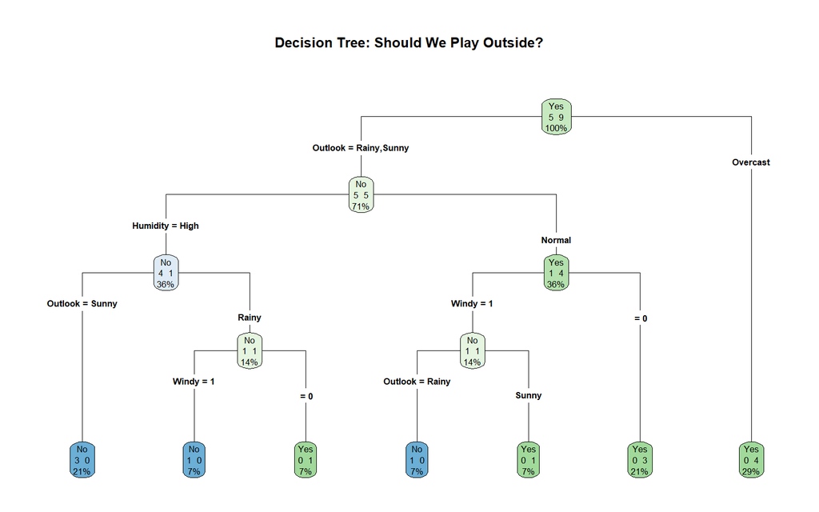

```r
rpart.plot(play_tree,
           type    = 4,
           extra   = 101,
           box.palette = "BuGn",
           main    = "Decision Tree: Should We Play Outside?")
```

## What Do the Numbers Inside Each Node Mean?

Every node in the plot produced by `rpart.plot(..., extra = 101)` displays **three lines**:

```
        ┌─────────────┐
        │     Yes     │  ← Line 1: Predicted class (majority class at this node)
        │     5  9    │  ← Line 2: Class counts in alphabetical order (No=5, Yes=9)
        │    100%     │  ← Line 3: % of total training data that reached this node
        └─────────────┘
```

Let’s trace each piece for the **root node** (`Yes | 5 9 | 100%`):

| Line | Value | Meaning |
| --- | --- | --- |
| **Predicted class** | `Yes` | The majority class: 9 Yes vs. 5 No, so the node predicts “Yes” |
| **Class counts** | `5 9` | 5 observations of class “No” and 9 of class “Yes” (alphabetical order) |
| **% of data** | `100%` | 14 out of 14 training instances pass through the root — always 100% |

Now trace a **leaf node** (`No | 3 0 | 21%`):

| Line | Value | Meaning |
| --- | --- | --- |
| **Predicted class** | `No` | All samples here are “No” — a perfectly pure leaf |
| **Class counts** | `3 0` | 3 “No” instances and 0 “Yes” instances |
| **% of data** | `21%` | 3 out of 14 total training instances end up at this leaf (3/14 ≈ 21%) |

**Branch direction:** The left branch always follows the condition printed above it (TRUE path); the right branch is FALSE. For example, the root splits on `Outlook = Rainy, Sunny` — observations where Outlook is Rainy or Sunny go **left**; Overcast goes **right**.

**Node color:** In the `BuGn` palette, **darker green = higher confidence “Yes”**; **blue = “No”**. The shade intensity reflects how pure the node is — a perfectly pure leaf is solid-colored, a mixed node is lighter.

**Key insight:** The percentages across all leaf nodes must add up to 100% — every training observation ends up in exactly one leaf. Checking this is a quick sanity test: 21% + 7% + 7% + 7% + 7% + 21% + 29% = 99% ≈ 100% (rounding).

```
## Root node breakdown:
```

```
##   Total observations:    14
```

```
##   Class 'No' count:      5 ( 36 % )
```

```
##   Class 'Yes' count:     9 ( 64 % )
```

```
##   Predicted class:       Yes (majority)
```

```
##   Gini impurity:         1 - ((5/14)^2 + (9/14)^2) = 0.459
```

**How to read this tree (summary):**

- The **root node** (top) sees 100% of the data and makes the first split.
- Each **internal node** applies a yes/no test. Left = condition TRUE; right = condition FALSE.
- Each **leaf node** shows the final prediction. Its class counts and % tell you exactly which training samples land there and how pure the node is.
- **A node with counts like `3 0`** is perfectly pure (Gini = 0) — ideal. **`1 1`** is maximally impure (Gini = 0.5).
- The **% of data** at a leaf tells you how often that rule applies to your training set — small percentages mean the rule fires rarely and may be unreliable on new data.

# Part 2: How Trees Decide Where to Split — The CART Algorithm

## The Core Idea: Impurity

The tree must decide which feature and which threshold to use at each node. It does this by measuring **impurity** — how mixed the classes are within each resulting group. A good split creates child nodes that are as **pure** (unmixed) as possible.

The algorithm used in `rpart` is **CART (Classification and Regression Trees)**. It is a **greedy algorithm**: at every node, it searches through every feature and every possible split threshold, picks the one that minimizes impurity in the two resulting child nodes, then repeats recursively.

> CART does *not* look ahead. It picks the locally best split at each step without checking if a suboptimal split now might lead to a better tree later. This is why we must settle for a “reasonably good” solution rather than a guaranteed optimal one.

## Gini Impurity

The default impurity measure in CART is **Gini Impurity**:

$$G_i = 1 - \sum_{k=1}^{n}
p_{i,k}^2$$

Where $p_{i,k}$ is the proportion of class $k$ instances at node $i$.

- **Gini = 0**: Node is perfectly pure (all one class)
- **Gini = 0.5**: Node is maximally impure (50/50 split between two classes)

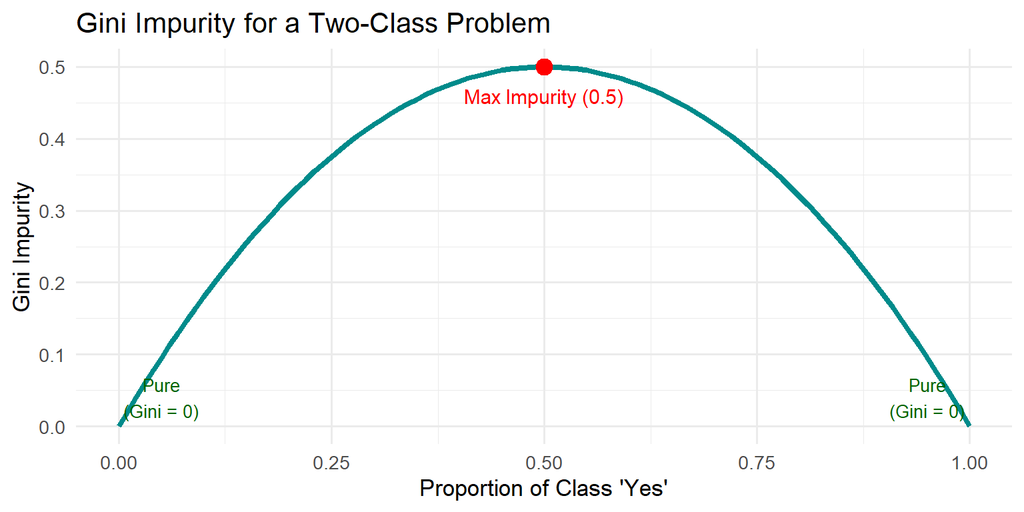

```r
calculate_gini <- function(p1) 1 - (p1^2 + (1 - p1)^2)

gini_df <- data.frame(p = seq(0, 1, 0.01)) |>
  mutate(gini = calculate_gini(p))

ggplot(gini_df, aes(x = p, y = gini)) +
  geom_line(color = "darkcyan", linewidth = 1.5) +
  geom_point(aes(x = 0.5, y = 0.5), color = "red", size = 4) +
  annotate("text", x = 0.5, y = 0.46, label = "Max Impurity (0.5)", color = "red", size = 4) +
  annotate("text", x = 0.05, y = 0.04, label = "Pure\n(Gini = 0)", color = "darkgreen", size = 3.5) +
  annotate("text", x = 0.95, y = 0.04, label = "Pure\n(Gini = 0)", color = "darkgreen", size = 3.5) +
  labs(title = "Gini Impurity for a Two-Class Problem",
       x = "Proportion of Class 'Yes'", y = "Gini Impurity") +
  theme_minimal(base_size = 13)
```

## Entropy — An Alternative Impurity Measure

**Entropy** is a second common impurity measure, borrowed from information theory. It measures the average *surprise* or uncertainty in a node:

$$H_i = -\sum_{k=1}^{n} p_{i,k}
\log_2(p_{i,k}) \quad (\text{terms where } p_{i,k} = 0 \text{ are set to
0})$$

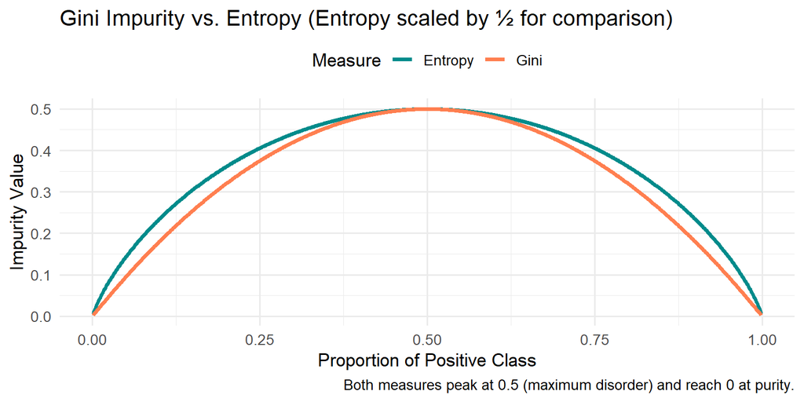

```r
entropy_fn <- function(p) {
  if (p == 0 | p == 1) return(0)
  -(p * log2(p) + (1 - p) * log2(1 - p))
}

compare_df <- data.frame(p = seq(0.001, 0.999, 0.001)) |>
  mutate(
    Gini    = calculate_gini(p),
    Entropy = sapply(p, entropy_fn) / 2  # scaled to [0,0.5] for visual comparison
  ) |>
  pivot_longer(c(Gini, Entropy), names_to = "Measure", values_to = "Value")

ggplot(compare_df, aes(x = p, y = Value, color = Measure)) +
  geom_line(linewidth = 1.4) +
  scale_color_manual(values = c("darkcyan", "coral")) +
  labs(title = "Gini Impurity vs. Entropy (Entropy scaled by ½ for comparison)",
       x = "Proportion of Positive Class", y = "Impurity Value",
       caption = "Both measures peak at 0.5 (maximum disorder) and reach 0 at purity.") +
  theme_minimal(base_size = 13) +
  theme(legend.position = "top")
```

**Which should you use?**

| Property | Gini | Entropy |
| --- | --- | --- |
| Computation | Faster (no logarithm) | Slightly slower |
| Behavior | Tends to isolate the most frequent class in its own branch | Tends to produce slightly more balanced trees |
| Default in `rpart` | Yes (`parms = list(split = "gini")`) | No (`parms = list(split = "information")`) |

In practice, they produce very similar trees. Gini is the standard default.

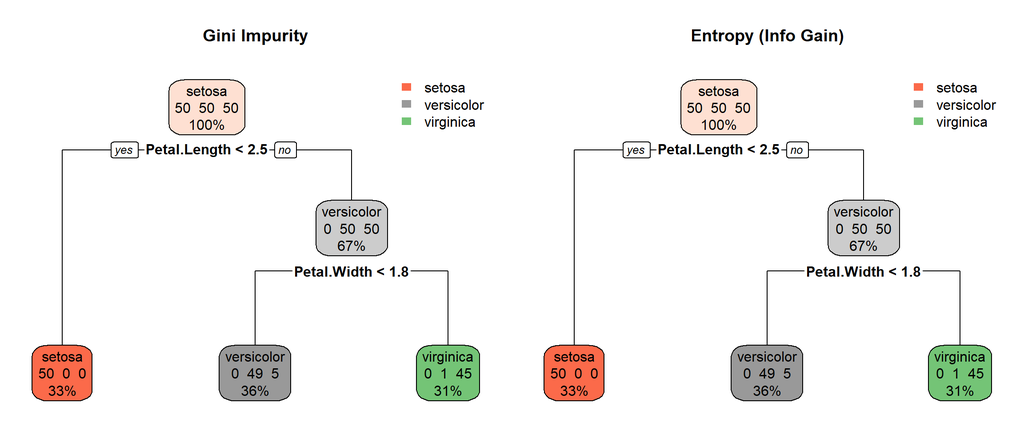

```r
par(mfrow = c(1, 2))

tree_gini <- rpart(Species ~ Petal.Length + Petal.Width, data = iris,
                   method = "class", parms = list(split = "gini"))
tree_entropy <- rpart(Species ~ Petal.Length + Petal.Width, data = iris,
                      method = "class", parms = list(split = "information"))

rpart.plot(tree_gini,    main = "Gini Impurity",  box.palette = "auto", extra = 101)
rpart.plot(tree_entropy, main = "Entropy (Info Gain)", box.palette = "auto", extra = 101)
```

```r
par(mfrow = c(1, 1))
```

## The CART Cost Function: A Worked Example

At every node, CART evaluates every possible split and picks the one minimizing this weighted cost:

$$J(k, t_k) = \frac{m_{\text{left}}}{m}
G_{\text{left}} + \frac{m_{\text{right}}}{m}
G_{\text{right}}$$

Let’s calculate this manually for the first split in the iris tree (`Petal.Length < 2.45`):

```r
# Reproduce the iris root split: Petal.Length < 2.45
left  <- iris[iris$Petal.Length < 2.45, ]   # setosa only
right <- iris[iris$Petal.Length >= 2.45, ]  # versicolor + virginica

gini_node <- function(df) {
  props <- table(df$Species) / nrow(df)
  1 - sum(props^2)
}

m       <- nrow(iris)
m_left  <- nrow(left)
m_right <- nrow(right)
G_left  <- gini_node(left)
G_right <- gini_node(right)
J       <- (m_left / m) * G_left + (m_right / m) * G_right

cat("--- Root split: Petal.Length < 2.45 ---\n")
```

```
## --- Root split: Petal.Length < 2.45 ---
```

```r
cat(sprintf("Left  node:  %d samples, Gini = %.4f\n", m_left,  G_left))
```

```
## Left  node:  50 samples, Gini = 0.0000
```

```r
cat(sprintf("Right node:  %d samples, Gini = %.4f\n", m_right, G_right))
```

```
## Right node:  100 samples, Gini = 0.5000
```

```r
cat(sprintf("Weighted cost J = (%.0f/%.0f)*%.4f + (%.0f/%.0f)*%.4f = %.4f\n",
            m_left, m, G_left, m_right, m, G_right, J))
```

```
## Weighted cost J = (50/150)*0.0000 + (100/150)*0.5000 = 0.3333
```

```r
cat("\nCART selects the (feature, threshold) pair that minimizes J.")
```

```
##
## CART selects the (feature, threshold) pair that minimizes J.
```

The left node is **pure** (Gini = 0): all 50 setosa fall there. The right node still has mixed versicolor and virginica, so CART will continue splitting it.

# Part 3: Estimating Class Probabilities

A Decision Tree does not just predict a class — it also returns the **probability** that an instance belongs to each class. This probability is simply the proportion of training instances of that class in the leaf node where the prediction lands.

```r
# Build a classification tree on iris using Petal features only
iris_tree <- rpart(Species ~ Petal.Length + Petal.Width,
                   data = iris, method = "class")

# --- Hard class prediction ---
new_flower <- data.frame(Petal.Length = 5.0, Petal.Width = 1.5)
pred_class  <- predict(iris_tree, new_flower, type = "class")
pred_prob   <- predict(iris_tree, new_flower, type = "prob")

cat("New flower: Petal.Length = 5.0 cm, Petal.Width = 1.5 cm\n\n")
```

```
## New flower: Petal.Length = 5.0 cm, Petal.Width = 1.5 cm
```

```r
cat("Predicted class:", as.character(pred_class), "\n\n")
```

```
## Predicted class: versicolor
```

```r
cat("Class probabilities:\n")
```

```
## Class probabilities:
```

```r
print(round(pred_prob, 4))
```

```
##   setosa versicolor virginica
## 1      0     0.9074    0.0926
```

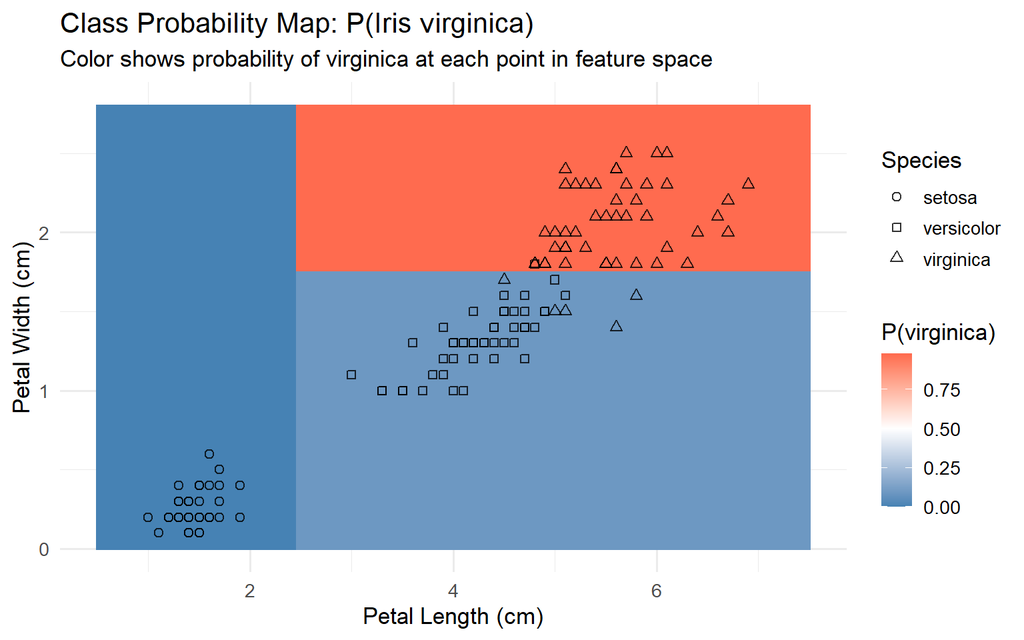

```r
# Create a prediction grid over the petal feature space
pl_range <- seq(0.5, 7.5, length.out = 200)
pw_range <- seq(0.0, 2.8, length.out = 200)
grid     <- expand.grid(Petal.Length = pl_range, Petal.Width = pw_range)

# Probability of being virginica
grid$prob_virginica <- predict(iris_tree, grid, type = "prob")[, "virginica"]

ggplot(grid, aes(x = Petal.Length, y = Petal.Width, fill = prob_virginica)) +
  geom_tile() +
  geom_point(data = iris, aes(x = Petal.Length, y = Petal.Width,
             shape = Species, fill = NULL), size = 2, alpha = 0.8) +
  scale_fill_gradient2(low = "steelblue", mid = "white", high = "tomato",
                       midpoint = 0.5, name = "P(virginica)") +
  scale_shape_manual(values = c(21, 22, 24)) +
  labs(title = "Class Probability Map: P(Iris virginica)",
       subtitle = "Color shows probability of virginica at each point in feature space",
       x = "Petal Length (cm)", y = "Petal Width (cm)") +
  theme_minimal(base_size = 13)
```

Notice that the probability is **constant within each rectangular region** — it jumps only at the split boundaries. This is fundamental to how trees make predictions: every point in the same leaf gets exactly the same probability vector.

# Part 4: Decision Boundaries

One of the most revealing ways to understand what a decision tree has learned is to visualize its **decision boundaries** — the lines that separate predicted classes in feature space.

Because CART splits on a single feature at a time, all boundaries are **axis-aligned rectangles**. This is an important limitation: if the true boundary is diagonal, the tree approximates it with a “staircase” of right-angle cuts.

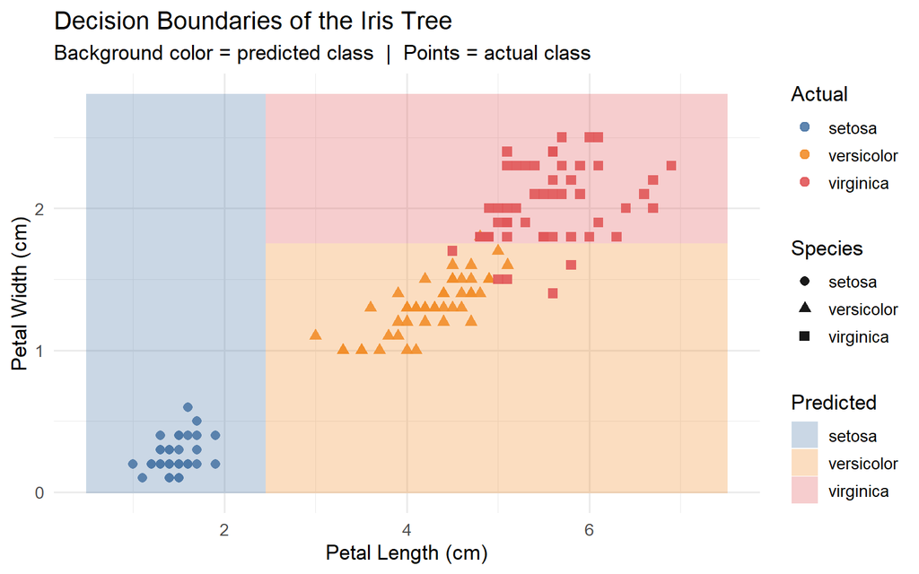

```r
# Grid prediction for all three species
grid$pred_class <- predict(iris_tree, grid, type = "class")

ggplot() +
  geom_tile(data = grid,
            aes(x = Petal.Length, y = Petal.Width, fill = pred_class),
            alpha = 0.3) +
  geom_point(data = iris,
             aes(x = Petal.Length, y = Petal.Width,
                 color = Species, shape = Species),
             size = 2.5, alpha = 0.9) +
  scale_fill_manual(values  = c("setosa" = "#4E79A7",
                                "versicolor" = "#F28E2B",
                                "virginica"  = "#E15759"),
                    name = "Predicted") +
  scale_color_manual(values = c("setosa" = "#4E79A7",
                                "versicolor" = "#F28E2B",
                                "virginica"  = "#E15759"),
                     name = "Actual") +
  labs(title = "Decision Boundaries of the Iris Tree",
       subtitle = "Background color = predicted class  |  Points = actual class",
       x = "Petal Length (cm)", y = "Petal Width (cm)") +
  theme_minimal(base_size = 13)
```

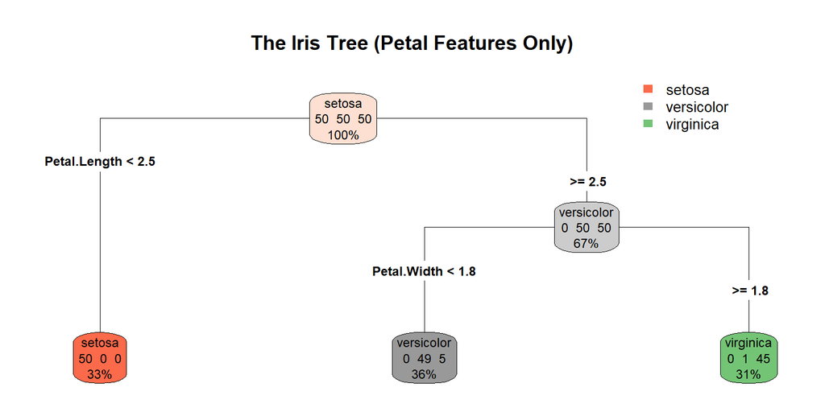

```r
rpart.plot(iris_tree, type = 4, extra = 101, box.palette = "auto",
           main = "The Iris Tree (Petal Features Only)")
```

**Tracing a prediction through the tree:**

1. **Start** at the root. Is `Petal.Length < 2.45`? → If YES → predict **setosa** (pure leaf, Gini = 0)
2. If NO, go right. Is `Petal.Width < 1.75`? → If YES → predict **versicolor**
3. If NO → predict **virginica**

# Part 5: Overfitting and Regularization

## The Overfitting Problem

If a tree is allowed to grow without any restriction, it will keep splitting until every leaf contains exactly one class — or even exactly one training instance. This is called **overfitting**: the tree memorizes the training data so precisely (including its noise) that it fails to generalize to new data.

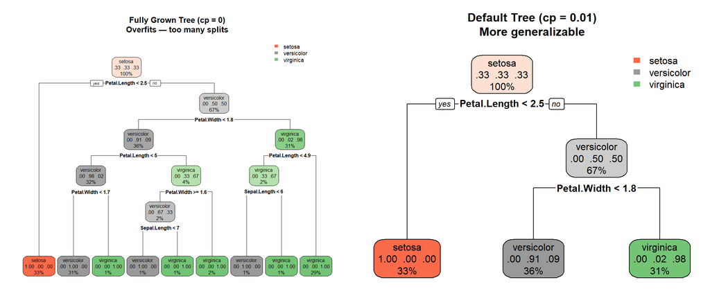

```r
par(mfrow = c(1, 2))

# Fully grown tree (default rpart already applies minimal stopping, but cp=0 grows more)
full_tree   <- rpart(Species ~ ., data = iris, method = "class",
                     control = rpart.control(cp = 0, minsplit = 2))
pruned_tree <- rpart(Species ~ ., data = iris, method = "class")

rpart.plot(full_tree,   main = "Fully Grown Tree (cp = 0)\nOverfits — too many splits", box.palette = "auto")
rpart.plot(pruned_tree, main = "Default Tree (cp = 0.01)\nMore generalizable", box.palette = "auto")
```

```r
par(mfrow = c(1, 1))
```

## Regularization with the Complexity Parameter (cp)

`rpart` uses a **complexity parameter (`cp`)** to penalize tree size. A split is only accepted if it improves the overall fit by at least `cp`. Larger `cp` → smaller, simpler tree.

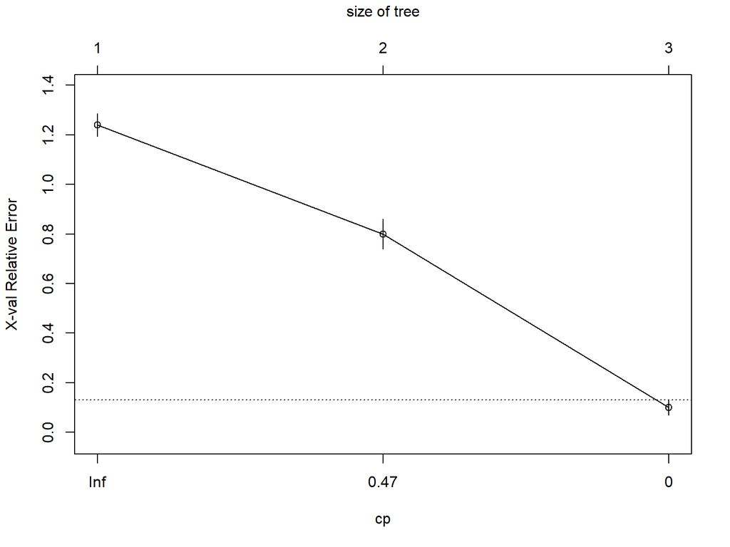

```r
full_iris_tree <- rpart(Species ~ ., data = iris, method = "class",
                        control = rpart.control(cp = 0))
plotcp(full_iris_tree)
```

```r
printcp(full_iris_tree)
```

```
##
## Classification tree:
## rpart(formula = Species ~ ., data = iris, method = "class", control = rpart.control(cp = 0))
##
## Variables actually used in tree construction:
## [1] Petal.Length Petal.Width
##
## Root node error: 100/150 = 0.66667
##
## n= 150
##
##     CP nsplit rel error xerror     xstd
## 1 0.50      0      1.00   1.24 0.046361
## 2 0.44      1      0.50   0.80 0.061101
## 3 0.00      2      0.06   0.10 0.030551
```

```r
# Select cp at the row with minimum cross-validated error
best_cp <- full_iris_tree$cptable[which.min(full_iris_tree$cptable[, "xerror"]), "CP"]
cat("Optimal cp selected:", round(best_cp, 4), "\n")
```

```
## Optimal cp selected: 0
```

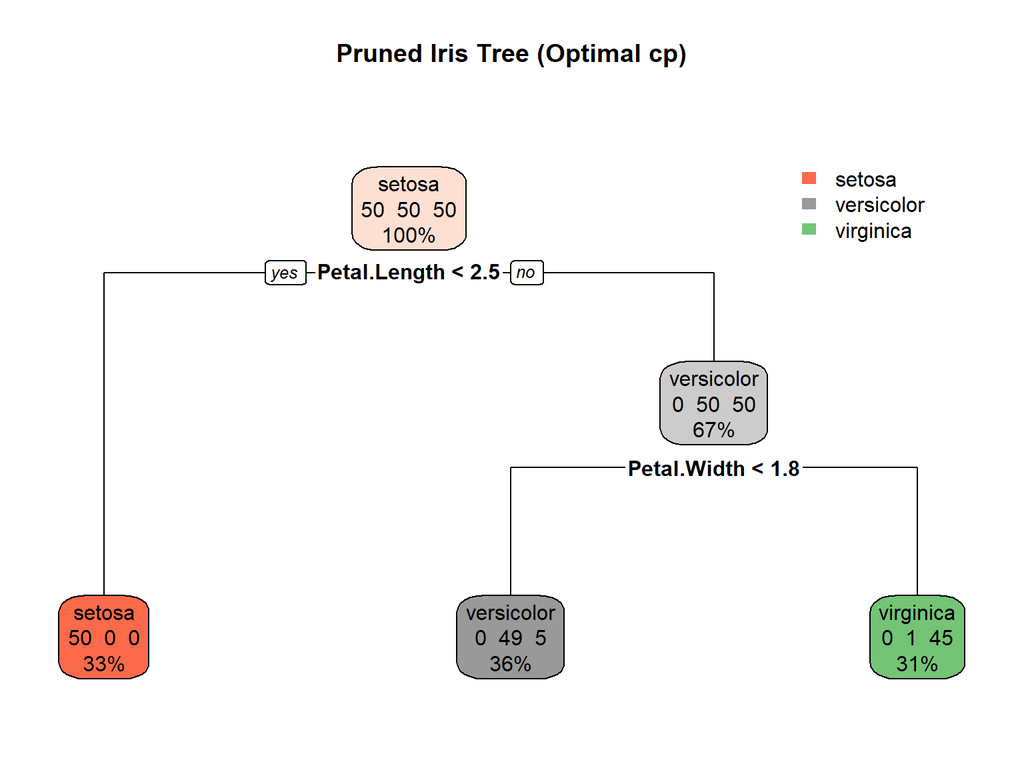

```r
pruned_iris_tree <- prune(full_iris_tree, cp = best_cp)

rpart.plot(pruned_iris_tree,
           main = "Pruned Iris Tree (Optimal cp)",
           box.palette = "auto", extra = 101)
```

## Regularization with Structural Hyperparameters

Beyond `cp`, `rpart` provides hyperparameters that directly constrain the tree’s structure. These are often more interpretable than `cp`:

| Parameter | What it controls | Effect of increasing |
| --- | --- | --- |
| `max_depth` | Maximum levels from root to leaf | Smaller tree |
| `minsplit` | Min samples needed to attempt a split | Fewer splits |
| `minbucket` | Min samples required in any leaf | Fewer, larger leaves |
| `max_leaf_nodes` | (via `maxdepth` in rpart) | Caps total leaves |

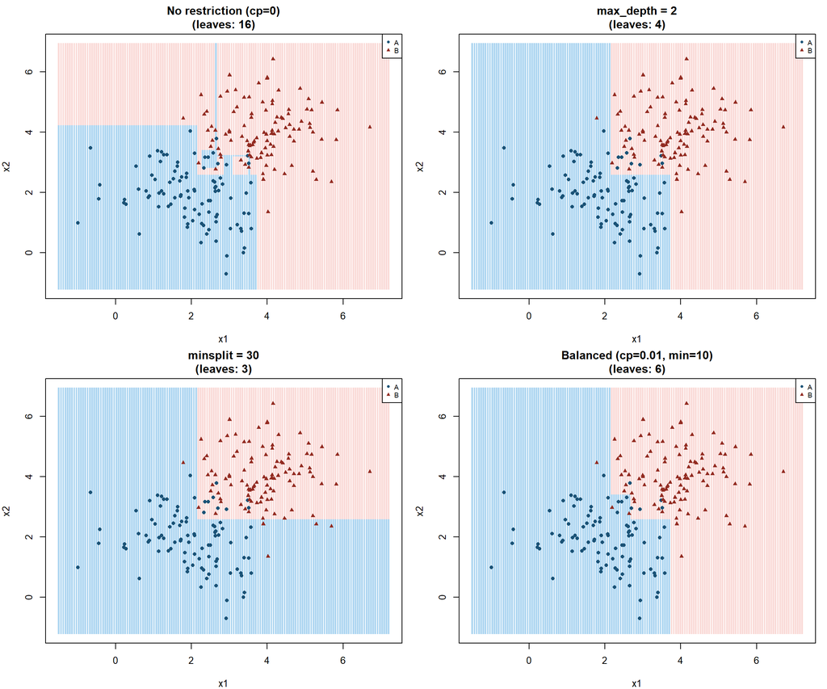

```r
# Create a noisier, harder dataset using the moons-like concept with iris
set.seed(42)
n <- 200
x1 <- c(rnorm(n/2, 2, 1), rnorm(n/2, 4, 1))
x2 <- c(rnorm(n/2, 2, 1), rnorm(n/2, 4, 1))
y  <- factor(ifelse(x1 + x2 + rnorm(n, 0, 0.5) < 6, "A", "B"))
noisy_data <- data.frame(x1, x2, y)

configs <- list(
  list(label = "No restriction (cp=0)",    cp = 0,    minsplit = 2,  maxdepth = 30),
  list(label = "max_depth = 2",            cp = 0,    minsplit = 2,  maxdepth = 2),
  list(label = "minsplit = 30",            cp = 0,    minsplit = 30, maxdepth = 30),
  list(label = "Balanced (cp=0.01, min=10)", cp = 0.01, minsplit = 10, maxdepth = 30)
)

par(mfrow = c(2, 2), mar = c(4, 4, 3, 1))

for (cfg in configs) {
  t <- rpart(y ~ x1 + x2, data = noisy_data, method = "class",
             control = rpart.control(cp = cfg$cp, minsplit = cfg$minsplit,
                                     maxdepth = cfg$maxdepth))
  grid2 <- expand.grid(x1 = seq(min(x1)-0.5, max(x1)+0.5, length.out = 150),
                        x2 = seq(min(x2)-0.5, max(x2)+0.5, length.out = 150))
  grid2$pred <- predict(t, grid2, type = "class")

  plot(grid2$x1, grid2$x2,
       col = ifelse(grid2$pred == "A", "#AED6F1", "#FADBD8"),
       pch = 15, cex = 0.4, xlab = "x1", ylab = "x2",
       main = sprintf("%s\n(leaves: %d)", cfg$label, sum(t$frame$var == "<leaf>")))
  points(noisy_data$x1, noisy_data$x2,
         col   = ifelse(noisy_data$y == "A", "#1A5276", "#922B21"),
         pch   = ifelse(noisy_data$y == "A", 16, 17),
         cex   = 0.8)
  legend("topright", legend = c("A","B"),
         col = c("#1A5276","#922B21"), pch = c(16,17), cex = 0.7)
}
```

```r
par(mfrow = c(1, 1))
```

**Reading the comparison:**

- **No restriction** — the tree carves out tiny rectangular pockets, memorizing every training point. Every wrinkle in the boundary is noise being fit.
- **max_depth = 2** — only 2 levels of splits. Very simple, may underfit complex patterns.
- **minsplit = 30** — refuses to split any node with fewer than 30 samples. Reduces fragmentation.
- **Balanced** — combines a small `cp` penalty with a minimum split count. Usually the best practical approach.

# Part 6: Instability — A Key Limitation

Decision trees are **highly sensitive to small changes in the training data**. Remove a single outlier, and you may get a completely different tree structure. This is called **instability**, and it is one of the most important limitations to understand.

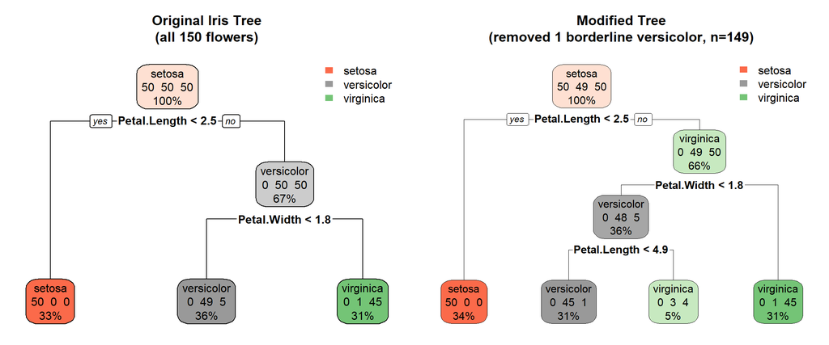

```r
par(mfrow = c(1, 2))

# Original iris tree
tree_original <- rpart(Species ~ Petal.Length + Petal.Width,
                       data = iris, method = "class")
rpart.plot(tree_original, main = "Original Iris Tree\n(all 150 flowers)",
           box.palette = "auto", extra = 101)

# Remove just ONE borderline versicolor flower
borderline_idx <- which(iris$Petal.Length == max(iris$Petal.Length[iris$Species == "versicolor"]) &
                          iris$Species == "versicolor")[1]
iris_modified <- iris[-borderline_idx, ]
tree_modified <- rpart(Species ~ Petal.Length + Petal.Width,
                       data = iris_modified, method = "class")
rpart.plot(tree_modified,
           main = sprintf("Modified Tree\n(removed 1 borderline versicolor, n=%d)", nrow(iris_modified)),
           box.palette = "auto", extra = 101)
```

```r
par(mfrow = c(1, 1))
```

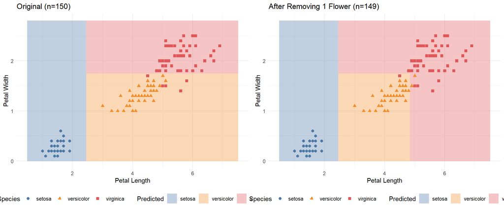

```r
grid_compare <- expand.grid(
  Petal.Length = seq(0.5, 7.5, length.out = 300),
  Petal.Width  = seq(0.0, 2.8, length.out = 300)
)
grid_compare$original <- predict(tree_original,  grid_compare, type = "class")
grid_compare$modified <- predict(tree_modified, grid_compare, type = "class")

p1 <- ggplot() +
  geom_tile(data = grid_compare,
            aes(x = Petal.Length, y = Petal.Width, fill = original), alpha = 0.35) +
  geom_point(data = iris, aes(x = Petal.Length, y = Petal.Width, color = Species, shape = Species),
             size = 2) +
  scale_fill_manual(values = c("setosa"="#4E79A7","versicolor"="#F28E2B","virginica"="#E15759"),
                    name="Predicted") +
  scale_color_manual(values = c("setosa"="#4E79A7","versicolor"="#F28E2B","virginica"="#E15759")) +
  labs(title = "Original (n=150)", x = "Petal Length", y = "Petal Width") +
  theme_minimal() + theme(legend.position = "bottom")

p2 <- ggplot() +
  geom_tile(data = grid_compare,
            aes(x = Petal.Length, y = Petal.Width, fill = modified), alpha = 0.35) +
  geom_point(data = iris_modified,
             aes(x = Petal.Length, y = Petal.Width, color = Species, shape = Species), size = 2) +
  scale_fill_manual(values = c("setosa"="#4E79A7","versicolor"="#F28E2B","virginica"="#E15759"),
                    name="Predicted") +
  scale_color_manual(values = c("setosa"="#4E79A7","versicolor"="#F28E2B","virginica"="#E15759")) +
  labs(title = "After Removing 1 Flower (n=149)", x = "Petal Length", y = "Petal Width") +
  theme_minimal() + theme(legend.position = "bottom")

gridExtra::grid.arrange(p1, p2, ncol = 2)
```

Even removing a single borderline observation can shift split thresholds and reorganize entire branches. This is why single decision trees are rarely used in production — **Random Forests** overcome this by averaging predictions across hundreds of trees built on random subsets of the data, making the ensemble much more stable.

# Part 7: Regression Trees

## How Regression Trees Work

Regression trees follow the same CART logic, but with two key changes:

1. **Splitting criterion**: Instead of minimizing Gini impurity, CART minimizes the **Mean Squared Error (MSE)** in the child nodes:

$$J(k, t_k) = \frac{m_{\text{left}}}{m}
\text{MSE}_{\text{left}} + \frac{m_{\text{right}}}{m}
\text{MSE}_{\text{right}}$$

2. **Leaf prediction**: The prediction is the **mean** of all training values that fall into that leaf — a single constant for the entire region.

## Building a Regression Tree

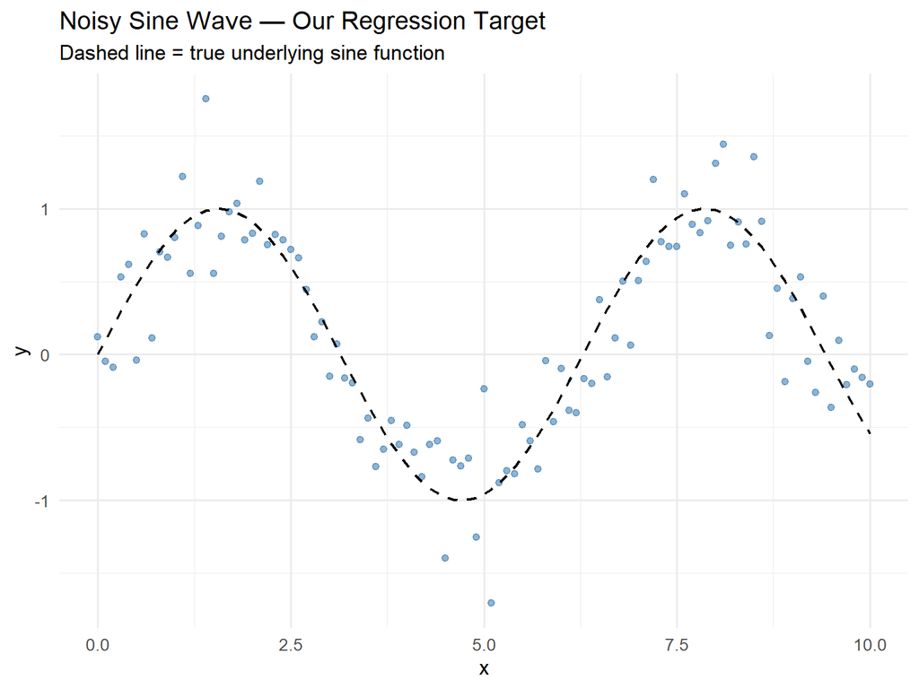

```r
x <- seq(0, 10, by = 0.1)
y <- sin(x) + rnorm(length(x), sd = 0.3)
regression_data <- data.frame(x, y)

ggplot(regression_data, aes(x = x, y = y)) +
  geom_point(alpha = 0.6, color = "steelblue") +
  geom_line(aes(y = sin(x)), color = "black", linewidth = 0.8, linetype = "dashed") +
  labs(title = "Noisy Sine Wave — Our Regression Target",
       subtitle = "Dashed line = true underlying sine function",
       x = "x", y = "y") +
  theme_minimal(base_size = 13)
```

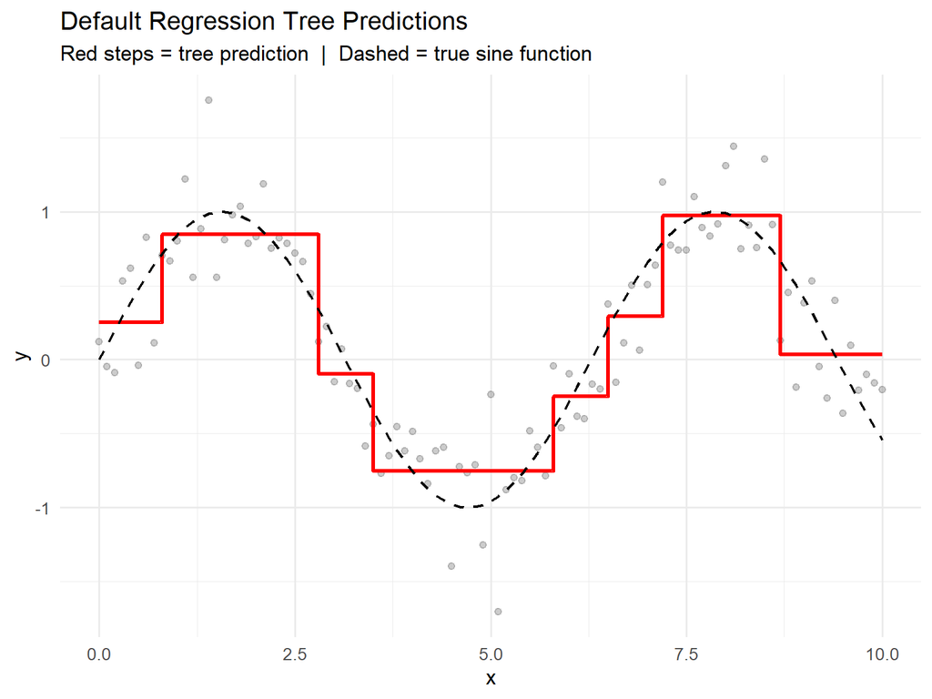

```r
regression_tree <- rpart(y ~ x, data = regression_data, method = "anova")
regression_data$predicted_y <- predict(regression_tree, regression_data)

ggplot(regression_data, aes(x = x, y = y)) +
  geom_point(alpha = 0.4, color = "gray50") +
  geom_step(aes(y = predicted_y), color = "red", linewidth = 1.2) +
  geom_line(aes(y = sin(x)), color = "black", linewidth = 0.8, linetype = "dashed") +
  labs(title    = "Default Regression Tree Predictions",
       subtitle  = "Red steps = tree prediction  |  Dashed = true sine function",
       x = "x", y = "y") +
  theme_minimal(base_size = 13)
```

The tree approximates the smooth curve with **step-wise constant values** — one constant per leaf region.

## Overfitting vs. Underfitting in Regression Trees

[figure not shown]

[output not shown]

```r
depths <- c(1, 3, 6, 15)
plots  <- list()

for (d in depths) {
  t <- rpart(y ~ x, data = regression_data, method = "anova",
             control = rpart.control(maxdepth = d, cp = 0))
  regression_data[[paste0("pred_d", d)]] <- predict(t, regression_data)
  n_leaves <- sum(t$frame$var == "<leaf>")

  plots[[as.character(d)]] <- ggplot(regression_data, aes(x = x)) +
    geom_point(aes(y = y), alpha = 0.3, color = "gray50") +
    geom_step(aes(y = .data[[paste0("pred_d", d)]]), color = "red", linewidth = 1) +
    geom_line(aes(y = sin(x)), color = "black", linewidth = 0.7, linetype = "dashed") +
    labs(title    = sprintf("max_depth = %d  (%d leaves)", d, n_leaves),
         subtitle = if (d <= 2) "Underfitting" else if (d >= 10) "Overfitting" else "Good fit",
         x = "x", y = "y") +
    theme_minimal(base_size = 11)
}

gridExtra::grid.arrange(grobs = plots, ncol = 2)
```

## The CART Cost Function in Action for Regression

```r
# Show MSE calculation for a candidate split in the regression tree
split_point <- 5.0
left_y  <- regression_data$y[regression_data$x <  split_point]
right_y <- regression_data$y[regression_data$x >= split_point]

mse_node <- function(vals) mean((vals - mean(vals))^2)

m       <- nrow(regression_data)
J_split <- (length(left_y)/m) * mse_node(left_y) + (length(right_y)/m) * mse_node(right_y)

cat("--- Candidate split: x < 5.0 ---\n")
```

```
## --- Candidate split: x < 5.0 ---
```

```r
cat(sprintf("Left  region: %d points, mean=%.3f, MSE=%.4f\n",
            length(left_y),  mean(left_y),  mse_node(left_y)))
```

```
## Left  region: 50 points, mean=0.146, MSE=0.5168
```

```r
cat(sprintf("Right region: %d points, mean=%.3f, MSE=%.4f\n",
            length(right_y), mean(right_y), mse_node(right_y)))
```

```
## Right region: 51 points, mean=0.178, MSE=0.4427
```

```r
cat(sprintf("Weighted cost J = %.4f\n", J_split))
```

```
## Weighted cost J = 0.4794
```

```r
cat("\nCART evaluates this cost for every possible x threshold and picks the minimum.")
```

```
##
## CART evaluates this cost for every possible x threshold and picks the minimum.
```

# Part 8: Advantages and Disadvantages

## Advantages

| Advantage | Why it matters |
| --- | --- |
| **White box model** | Every decision is traceable — you can follow the exact path from input to prediction. Unlike neural networks, you can explain a tree’s decision to a non-technical stakeholder. |
| **No feature scaling needed** | Trees split on individual feature thresholds, so standardization or normalization is irrelevant. |
| **Handles mixed data types** | Categorical and numerical features can live in the same tree without preprocessing. |
| **Non-linear patterns** | Trees are not limited to linear boundaries — they can model complex, non-monotonic relationships. |
| **Fast prediction** | Prediction is O(log₂ m) — just traversing from root to leaf. Very efficient even for large datasets. |
| **Built-in feature selection** | Features that don’t improve purity are simply never used. The tree implicitly selects the most informative features. |

## Disadvantages

| Disadvantage | Details |
| --- | --- |
| **Overfitting** | Unconstrained trees memorize training noise. Requires careful regularization. |
| **Instability** | Small data changes can completely restructure the tree. Random Forests solve this by averaging many trees. |
| **Orthogonal boundaries only** | All splits are axis-aligned. Diagonal or curved true boundaries are approximated inefficiently with many steps. |
| **Greedy algorithm** | CART picks the locally best split at each node, which is not guaranteed to produce the globally optimal tree (this is NP-Complete). |
| **Biased toward high-cardinality features** | Features with many possible split points get more chances to be selected. Use `cp` and `minsplit` to mitigate this. |

## Computational Complexity

| Operation | Complexity |
| --- | --- |
| **Prediction** | O(log₂ m) — traverse from root to leaf |
| **Training** | O(n × m log₂ m) — compare n features across m samples at each split |

Decision trees are fast to predict and reasonably fast to train. The main cost is finding the best split at each node, which requires checking every feature at every possible threshold.

# Part 9: From Trees to Forests — A Preview

The instability and overfitting tendency of single decision trees motivated the development of **Random Forests**: an ensemble of many trees, each built on a random subset of the data and a random subset of the features. The final prediction is the **majority vote** (classification) or **average** (regression) across all trees.

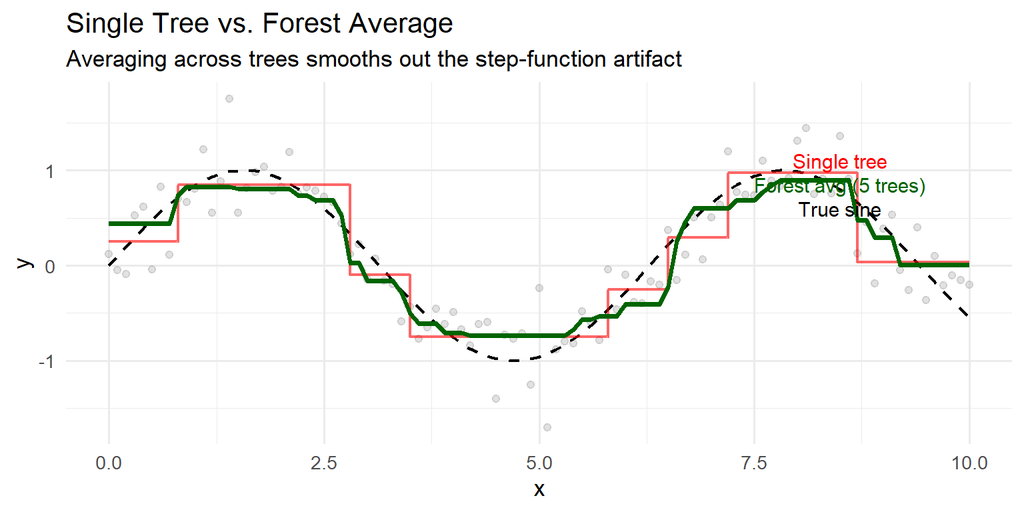

```r
# Simulate what happens when we average 5 differently-sampled regression trees
set.seed(42)
n_trees  <- 5
all_preds <- matrix(NA, nrow = nrow(regression_data), ncol = n_trees)

for (i in seq_len(n_trees)) {
  boot_idx <- sample(nrow(regression_data), replace = TRUE)
  boot_dat <- regression_data[boot_idx, c("x", "y")]
  t_i      <- rpart(y ~ x, data = boot_dat, method = "anova",
                    control = rpart.control(maxdepth = 4, cp = 0))
  all_preds[, i] <- predict(t_i, regression_data)
}

regression_data$forest_avg <- rowMeans(all_preds)

ggplot(regression_data, aes(x = x)) +
  geom_point(aes(y = y), alpha = 0.3, color = "gray60") +
  geom_line(aes(y = sin(x)), color = "black", linewidth = 0.8, linetype = "dashed") +
  geom_step(aes(y = predicted_y), color = "red",    linewidth = 0.8, alpha = 0.6) +
  geom_line(aes(y = forest_avg),  color = "darkgreen", linewidth = 1.4) +
  annotate("text", x = 8.5, y = 1.1,  label = "Single tree", color = "red",       size = 4) +
  annotate("text", x = 8.5, y = 0.85, label = "Forest avg (5 trees)", color = "darkgreen", size = 4) +
  annotate("text", x = 8.5, y = 0.6,  label = "True sine",   color = "black",     size = 4) +
  labs(title    = "Single Tree vs. Forest Average",
       subtitle  = "Averaging across trees smooths out the step-function artifact",
       x = "x", y = "y") +
  theme_minimal(base_size = 13)
```

The ensemble average is visibly smoother and closer to the true function than any single tree. This motivates **Week 3: Random Forests**.

# Part 10: Feature Importance

## What is Feature Importance?

When a tree splits on a feature, it reduces the impurity (or error) at that node. Summing this reduction across every split where a feature is used gives its **total contribution** to the model’s predictive power. Features that are never used in any split have zero importance.

As described by Boehmke & Greenwell **[2]**:

> *“To measure feature importance, the reduction in the loss function (e.g., SSE) attributed to each variable at each split is tabulated. In some instances, a single variable could be used multiple times in a tree; consequently, the total reduction in the loss function across all splits by a variable are summed up and used as the total feature importance.”*

This means **a single feature can appear in multiple splits** — and its importance accumulates across all of them.

## Feature Importance for Classification (Iris)

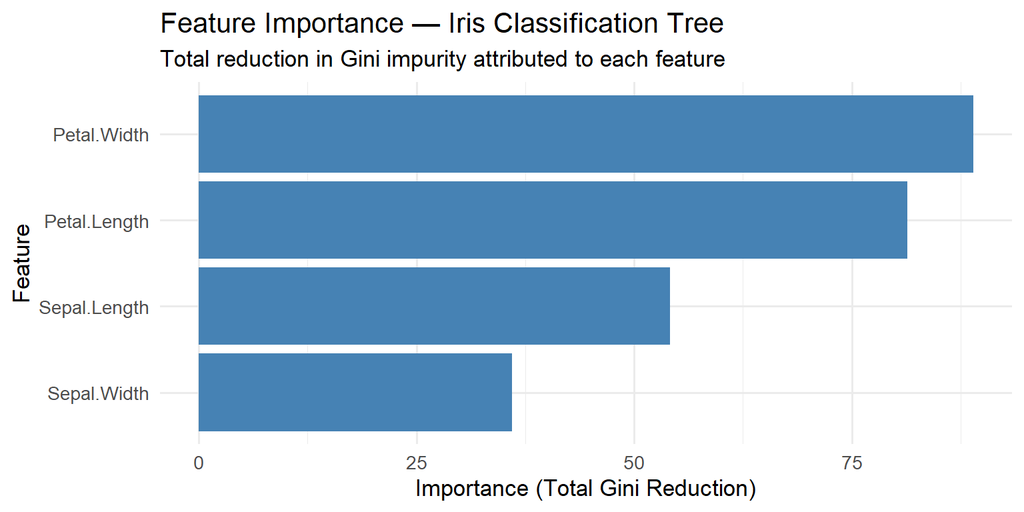

```r
# Build a full classification tree on all iris features
iris_full_tree <- rpart(Species ~ ., data = iris, method = "class",
                        control = rpart.control(cp = 0.001))

# rpart stores total impurity reduction per feature in $variable.importance
imp <- iris_full_tree$variable.importance
imp_df <- data.frame(
  Feature    = names(imp),
  Importance = as.numeric(imp)
) |> arrange(Importance)

ggplot(imp_df, aes(x = reorder(Feature, Importance), y = Importance)) +
  geom_col(fill = "steelblue") +
  coord_flip() +
  labs(title    = "Feature Importance — Iris Classification Tree",
       subtitle  = "Total reduction in Gini impurity attributed to each feature",
       x = "Feature", y = "Importance (Total Gini Reduction)") +
  theme_minimal(base_size = 13)
```

```r
# Access the raw importance values
imp <- iris_full_tree$variable.importance
imp_df <- data.frame(
  Feature    = names(imp),
  Importance = round(imp, 2),
  Pct        = round(100 * imp / sum(imp), 1)
) |> arrange(desc(Importance))

knitr::kable(imp_df, col.names = c("Feature", "Importance (Gini Reduction)", "% of Total"),
             caption = "Feature importance values from the iris classification tree")
```

Feature importance values from the iris classification tree

|  | Feature | Importance (Gini Reduction) | % of Total |
| --- | --- | --- | --- |
| Petal.Width | Petal.Width | 88.97 | 34.2 |
| Petal.Length | Petal.Length | 81.34 | 31.2 |
| Sepal.Length | Sepal.Length | 54.10 | 20.8 |
| Sepal.Width | Sepal.Width | 36.01 | 13.8 |

## Feature Importance for Regression

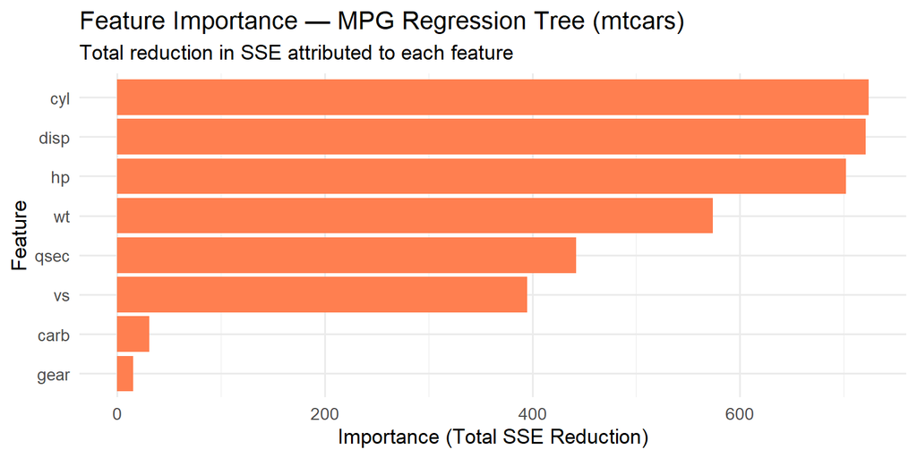

```r
# Regression tree on mtcars: predict fuel efficiency (mpg) from car attributes
reg_tree_cars <- rpart(mpg ~ ., data = mtcars, method = "anova",
                       control = rpart.control(cp = 0.01))

imp_reg <- reg_tree_cars$variable.importance
imp_reg_df <- data.frame(
  Feature    = names(imp_reg),
  Importance = as.numeric(imp_reg)
) |> arrange(Importance)

ggplot(imp_reg_df, aes(x = reorder(Feature, Importance), y = Importance)) +
  geom_col(fill = "coral") +
  coord_flip() +
  labs(title    = "Feature Importance — MPG Regression Tree (mtcars)",
       subtitle  = "Total reduction in SSE attributed to each feature",
       x = "Feature", y = "Importance (Total SSE Reduction)") +
  theme_minimal(base_size = 13)
```

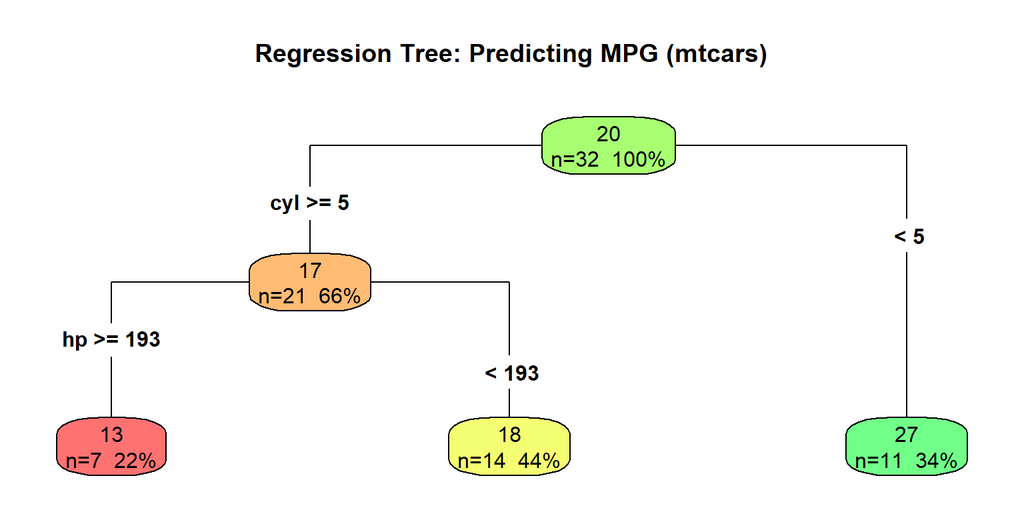

```r
rpart.plot(reg_tree_cars, type = 4, extra = 101, box.palette = "RdYlGn",
           main = "Regression Tree: Predicting MPG (mtcars)")
```

> **Note:** Decision trees perform **automatic feature selection** — features that provide no impurity reduction simply never appear in the tree, and their importance is zero. Unlike regression models, you do not need to manually remove uninformative features. **[2]**